# Лабораторная работа №5

Управление системными службами (systemd)

Ришард Когенгар

Российский университет дружбы народов, Москва, Россия

19 января 2026

# Цель работы

## Основная цель

Получить навыки управления системными службами операционной системы посредством systemd.

# Ход выполнения работы

## Управление системными службами (vsftpd)

- Получены полномочия администратора
- Проверен статус службы Very Secure FTP (vsftpd)
- Выполнена установка пакета vsftpd
- Служба запущена и проверена её работоспособность

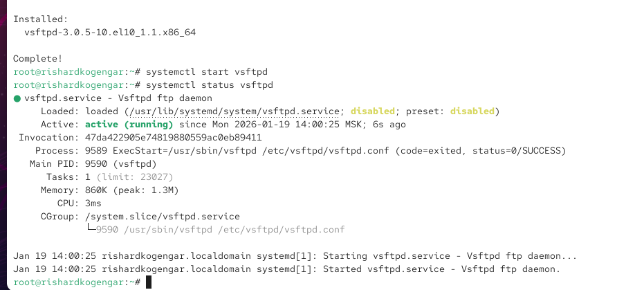

Запуск vsftpd и проверка статуса

## Автозапуск службы (enable/disable)

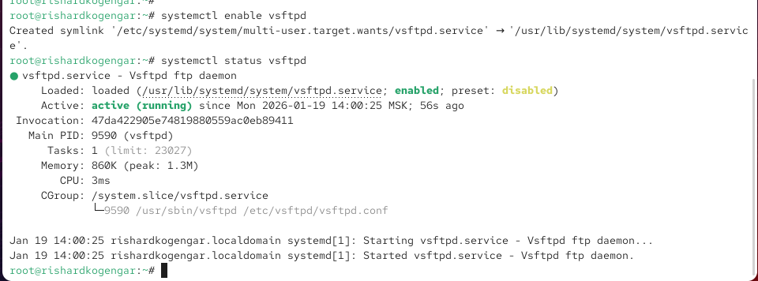

Включение автозапуска vsftpd

## Автозапуск и зависимости vsftpd

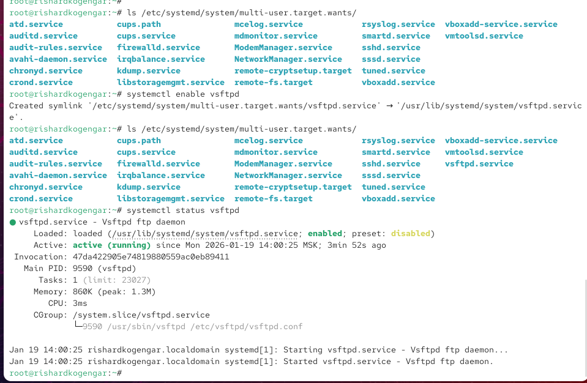

Проверка символических ссылок и повторное включение автозапуска

## Установка iptables и проверка статусов

- Установлены пакеты iptables и компоненты подсистемы
- Проверено состояние служб firewalld и iptables
- Зафиксировано, что firewalld активен, а iptables не запущен

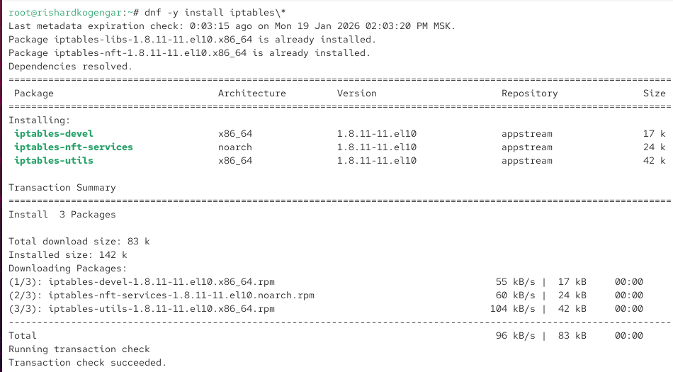

Установка пакетов iptables

## Демонстрация конфликта firewalld и iptables

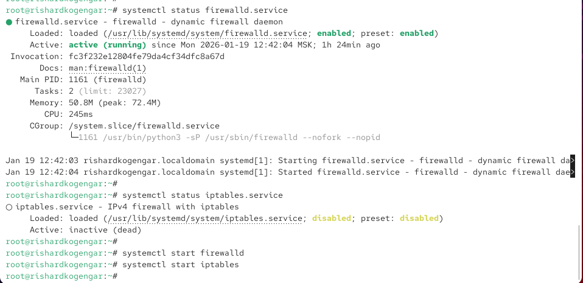

Статус firewalld и iptables

## Анализ конфликтов в файле юнита firewalld

- Просмотр конфигурации firewalld.service
- Обнаружена директива Conflicts
- Conflicts запрещает совместную работу с iptables/ip6tables/ebtables/ipset

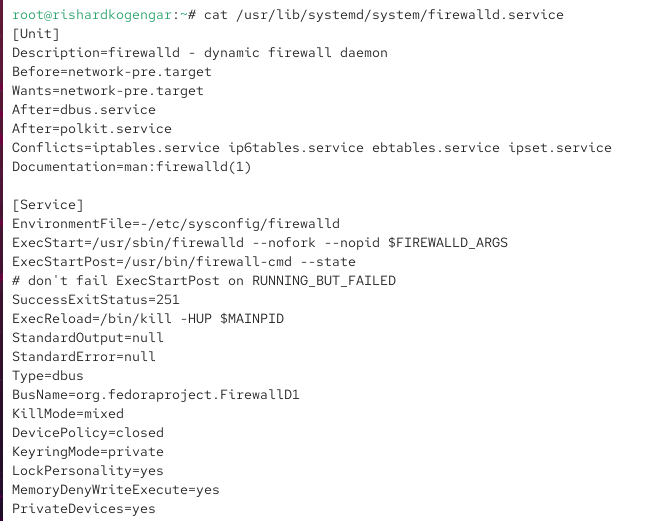

Содержимое firewalld.service

## Анализ файла юнита iptables

- Просмотр iptables.service
- Тип сервиса oneshot (инициализация правил)
- Сервис предназначен для настройки IPv4-фильтрации и не ориентирован на параллельную работу с firewalld

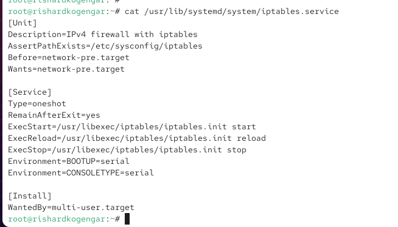

Содержимое iptables.service

## Маскирование iptables (mask)

- Остановлена служба iptables и запущен firewalld
- Выполнено mask для iptables (создание ссылки на /dev/null)
- Попытка запуска и включения в автозапуск завершилась ошибкой из-за masked

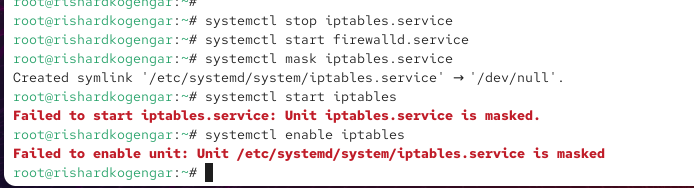

Маскирование службы iptables и ошибка запуска

## Поиск изолируемых целей (AllowIsolate)

- Переход в каталог /usr/lib/systemd/system
- Поиск целей с признаком AllowIsolate=yes
- Получен перечень целей, которые можно изолировать (switch state)

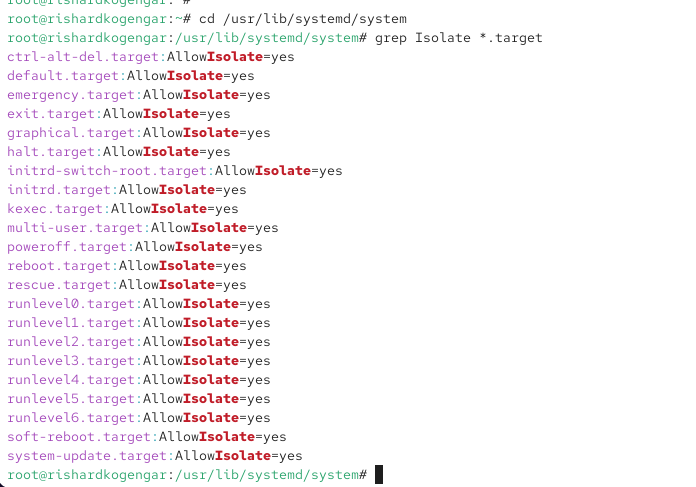

Список изолируемых целей

## Переход в режим восстановления (rescue.target)

- Выполнена изоляция rescue.target
- Система перешла в минимальный режим обслуживания
- Выполнен вход под root для дальнейших действий

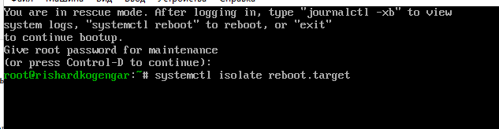

Переход в rescue.target

## Проверка текущей цели

- Определена цель загрузки по умолчанию
- Зафиксировано текущее значение default target

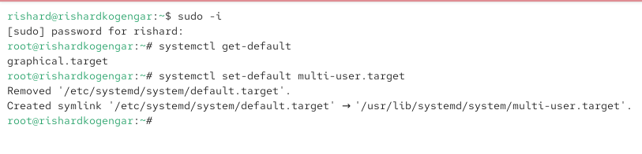

Определение цели по умолчанию

## Смена цели по умолчанию

- Установлена цель multi-user.target (текстовый режим)
- После перезагрузки подтверждён запуск в консольном режиме
- Выполнен возврат к graphical.target (графический режим)

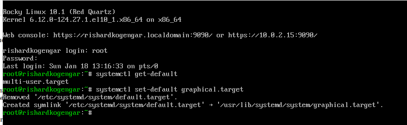

Возврат к graphical.target

# Итоги работы